# RQ1

# RQ1 — Differential expression

### Which genes are differentially expressed between patients with complete response and patients with progressive disease following anti-PD-L1 treatment?

Suggested tasks:

- Prepare and explore the gene-expression data, including appropriate filtering and normalization.
- Perform differential expression analysis between responders/non-responder using DESeq2, and identify significantly differentially expressed genes
- Visualize the results using e.g. volcano plots and heatmaps of selected genes.
- Investigate the biological functions of differentially expressed genes and discuss their potential relevance to immunotherapy response.
- Discuss the limitations of the analysis, including potential confounding factors and why differential expression does not necessarily imply a causal role in treatment response.

## 1. Data preparation

### Load packages and data

```r
# Load order matters: tidyverse (dplyr) is loaded last so that dplyr::select,
# filter and slice are not masked by AnnotationDbi / IRanges / BiocGenerics.
library(DESeq2)
library(fgsea)
library(msigdbr)
library(data.table)
library(pheatmap)
library(ggrepel)
library(tidyverse)
# Significance threshold used throughout the document
padj_cut <- 0.05

# Set group colorscheme
group_colours <- c(NR = "#D9534F", R = "#2E86C1")

# Helper: "GOBP_CELL_MIGRATION" -> "Cell migration" (optionally wrapped)
clean_label <- function(x, width = NULL) {
  x <- x |>
    str_remove("^GOBP_") |>
    str_replace_all("_", " ") |>
    str_to_sentence()
  if (is.null(width)) x else str_wrap(x, width = width)
}

# Load datasets
counts   <- readRDS("../data/counts.rds")
clinical <- readRDS("../data/clinical.rds")
```

### Check that samples match

```r
# Samples must be identical and in the same order in both datasets
stopifnot(identical(colnames(counts), clinical$sample_id))

clinical <- as.data.frame(clinical)
rownames(clinical) <- clinical$sample_id
stopifnot(identical(colnames(counts), rownames(clinical)))

dim(counts)             # genes x samples
```

```
[1] 31087   192
```

```r
head(rownames(counts))  # gene names
```

```
[1] "A1BG"    "NAT2"    "ADA"     "CDH2"    "AKT3"    "GAGE12F"
```

All samples are present in both datasets and in the same order, so no filtering of samples is needed.

### Response as a two-level factor

```r
# NR is the reference level, so a positive log2 fold change
# (and a positive NES later on) means "higher in responders (R)".
clinical$BOR <- factor(clinical$BOR, levels = c("NR", "R"))
stopifnot(!anyNA(clinical$BOR))   # fails if BOR contained any other category

table(clinical$BOR)
```

```
 NR   R
167  25
```

## 2. Differential expression with DESeq2

### Build the DESeq2 dataset and filter low-count genes

```r
dds <- DESeqDataSetFromMatrix(countData = counts,
                              colData   = clinical,  # sample metadata
                              design    = ~ BOR)     # R vs NR

n_genes_before <- nrow(dds)

# Keep genes with at least 10 reads in total across all samples
dds <- dds[rowSums(counts(dds)) >= 10, ]
n_genes_after <- nrow(dds)

c(before = n_genes_before, after = n_genes_after)
```

```
before  after
 31087  23003
```

### Run DESeq2 and extract results

DESeq2 normalizes the counts internally with the median-of-ratios method (size factors), so the raw counts are used as input.

```r
dds <- DESeq(dds)
```

```
-- replacing outliers and refitting for 2464 genes
-- DESeq argument 'minReplicatesForReplace' = 7
-- original counts are preserved in counts(dds)
```

```r
resultsNames(dds)   # "BOR_R_vs_NR"
```

```
[1] "Intercept"   "BOR_R_vs_NR"
```

```r
# Contrast means positive log2FC = higher in R
res <- results(dds, contrast = c("BOR", "R", "NR"), alpha = padj_cut)
summary(res)
```

```
out of 23000 with nonzero total read count
adjusted p-value < 0.05
LFC > 0 (up)       : 167, 0.73%
LFC < 0 (down)     : 278, 1.2%
outliers [1]       : 0, 0%
low counts [2]     : 3571, 16%
(mean count < 1)
[1] see 'cooksCutoff' argument of ?results
[2] see 'independentFiltering' argument of ?results
```

```r
res_tbl <- as.data.frame(res) |>
  rownames_to_column("gene") |>
  as_tibble() |>
  drop_na(padj, log2FoldChange) |>
  mutate(
    group = case_when(
      padj < padj_cut & log2FoldChange > 0 ~ "Up in responders",
      padj < padj_cut & log2FoldChange < 0 ~ "Up in non-responders",
      TRUE ~ "Not significant"
    )
  )

n_tested <- nrow(res_tbl)
n_up     <- sum(res_tbl$group == "Up in responders")
n_down   <- sum(res_tbl$group == "Up in non-responders")

# Top 10 genes by adjusted p-value
res_tbl |>
  filter(group != "Not significant") |>
  arrange(padj) |>
  select(gene, group, baseMean, log2FoldChange, padj) |>
  head(10)
```

```
# A tibble: 10 × 5
   gene  group                baseMean log2FoldChange          padj
   <chr> <chr>                   <dbl>          <dbl>         <dbl>
 1 ALB   Up in non-responders  1796.            -5.27 0.00000000565
 2 HABP2 Up in non-responders   131.            -4.40 0.000000553
 3 MYH15 Up in responders        79.0            1.97 0.00000205
 4 FGB   Up in non-responders   200.            -5.61 0.00000224
 5 KRT75 Up in non-responders    50.7           -4.78 0.00000225
 6 MUC2  Up in non-responders  6168.            -3.40 0.0000105
 7 TENM2 Up in non-responders   794.            -3.06 0.0000261
 8 MUC6  Up in non-responders   213.            -3.37 0.0000282
 9 WDR87 Up in responders         4.24           2.88 0.0000282
10 PRSS2 Up in non-responders   120.            -4.02 0.0000295
```

### Sample level overview

```r
# Variance-stabilising transformation for visualisation only (not used for the DE test)
vsd <- vst(dds, blind = TRUE) # could also have been log2 transformation, vst is build specifically for rna seq count data

pca <- plotPCA(vsd, intgroup = "BOR") +
  scale_color_manual(values = group_colours) +
  labs(title = "PCA of variance-stabilised counts") +
  theme_minimal()
```

```
using ntop=500 top features by variance
```

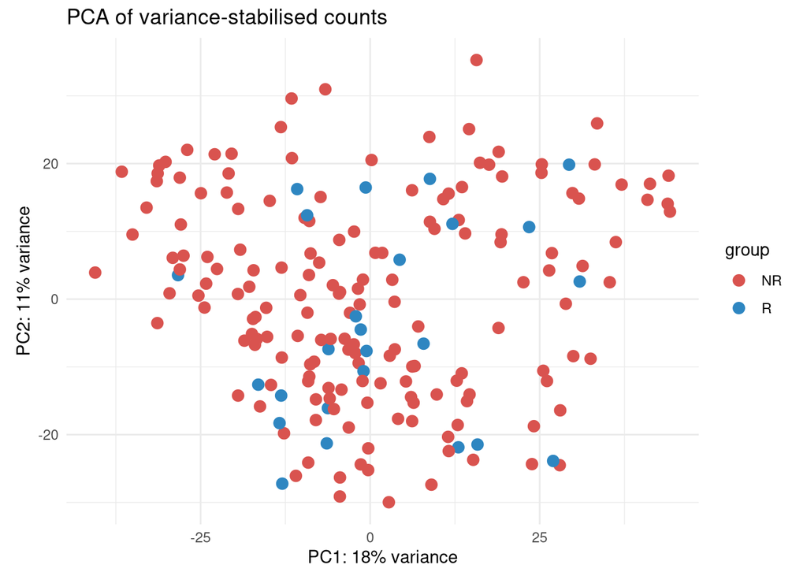

```r
pca
```

```r
ggsave("images/pca.pdf", pca, width = 10, height = 6, device = cairo_pdf)
```

#### Interpretation

Not divided by response, not the main driver of seperation (age, sex, batch effect, TMB etc etc)

29% variance explained

### Volcano plot

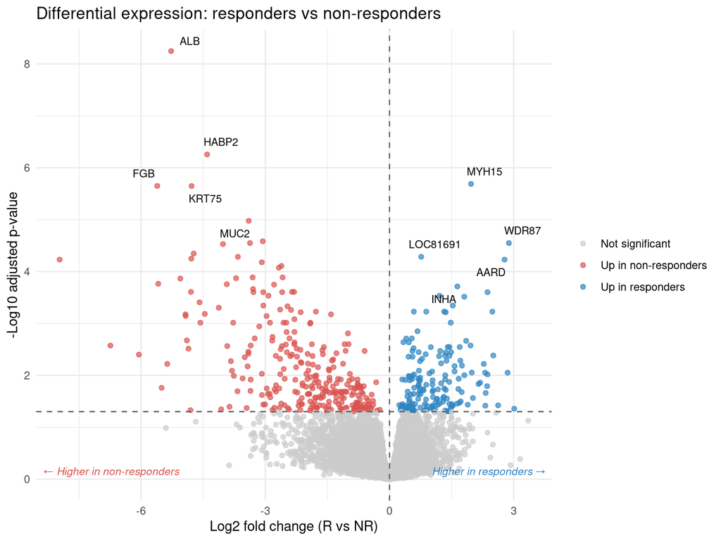

```r
# Label the 5 most significant genes in each direction
gene_labels <- res_tbl |>
  filter(group != "Not significant") |>
  group_by(group) |>
  slice_min(padj, n = 5, with_ties = FALSE) |>
  ungroup()

ggplot(res_tbl, aes(x = log2FoldChange, y = -log10(padj))) +
  geom_point(aes(color = group), alpha = 0.7) +
  geom_vline(xintercept = 0, linetype = "dashed", color = "grey40") +
  geom_hline(yintercept = -log10(padj_cut), linetype = "dashed", color = "grey40") +
  scale_color_manual(
    name = NULL,
    values = c("Up in responders"     = group_colours[["R"]],
               "Up in non-responders" = group_colours[["NR"]],
               "Not significant"      = "grey80")
  ) +
  geom_text_repel(data = gene_labels, aes(label = gene),
                  size = 3, max.overlaps = Inf, box.padding = 0.4) +
  annotate("text", x = Inf, y = 0, label = "Higher in responders \u2192",
           hjust = 1.05, vjust = -0.5, size = 3,
           fontface = "italic", color = group_colours[["R"]]) +
  annotate("text", x = -Inf, y = 0, label = "\u2190 Higher in non-responders",
           hjust = -0.05, vjust = -0.5, size = 3,
           fontface = "italic", color = group_colours[["NR"]]) +
  labs(x = "Log2 fold change (R vs NR)",
       y = "-Log10 adjusted p-value",
       title = "Differential expression: responders vs non-responders") +
  theme_minimal()
```

*Figure: Volcano plot of the DESeq2 results. Coloured points have an adjusted p-value below `padj_cut`. The five most significant genes in each direction are labelled.*

#### Interpretation

Consider not the most significant but the most out Log2FC’s

### Heatmap of the top differentially expressed genes

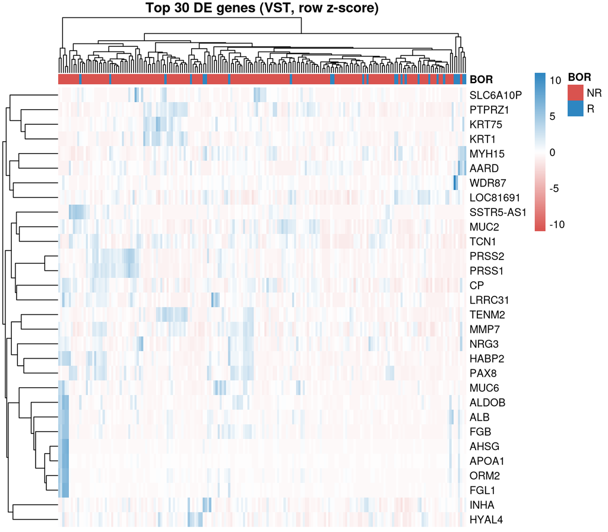

```r
top_genes <- res_tbl |>
  filter(group != "Not significant") |>
  slice_min(padj, n = 30, with_ties = FALSE) |>
  pull(gene)

if (length(top_genes) >= 2) {
  mat <- assay(vsd)[top_genes, ]
  ann <- as.data.frame(colData(vsd)[, "BOR", drop = FALSE])

  pheatmap(mat,
           scale             = "row",   # z-score per gene
           annotation_col    = ann,
           annotation_colors = list(BOR = group_colours),
           color             = colorRampPalette(c(group_colours[["NR"]], "white", group_colours[["R"]]))(100),
           show_colnames     = FALSE,
           main              = "Top 30 DE genes (VST, row z-score)")
}
```

*Figure: Heatmap of the 30 most significant genes. Samples (columns) are clustered by expression and the bar at the top shows their response group.*

## 3. Gene set enrichment analysis (GSEA)

Gene-level tests only look at individual genes. GSEA asks whether whole biological processes are shifted towards one group, which is more robust when many genes change a little.

### Gene sets and gene ranking

```r
# GO Biological Process gene sets from MSigDB.
# (msigdbr >= 10 uses collection/subcollection, older versions category/subcategory)
gene_sets <- if (packageVersion("msigdbr") >= "10.0.0") {
  msigdbr(species = "Homo sapiens", collection = "C5", subcollection = "GO:BP")
} else {
  msigdbr(species = "Homo sapiens", category = "C5", subcategory = "GO:BP")
}

pathways <- split(gene_sets$gene_symbol, gene_sets$gs_name) |>
  lapply(unique)
length(pathways)
```

```
[1] 7658
```

```r
# Rank all genes by the DESeq2 Wald statistic (sign = direction, size = confidence).
# If a symbol occurs more than once, keep the row with the strongest statistic.
ranked_df <- tibble(gene = rownames(res), stat = res$stat) |>
  filter(!is.na(stat), !is.na(gene), gene != "") |>
  arrange(desc(abs(stat))) |>
  distinct(gene, .keep_all = TRUE)

ranked_genes <- sort(setNames(ranked_df$stat, ranked_df$gene), decreasing = TRUE)

# Sanity checks on the ranked list
tibble(
  n_ranked_genes = length(ranked_genes),
  n_in_GOBP      = sum(names(ranked_genes) %in% gene_sets$gene_symbol),
  pct_ties       = 100 * mean(duplicated(ranked_genes))
)
```

```
# A tibble: 1 × 3
  n_ranked_genes n_in_GOBP pct_ties
           <int>     <int>    <dbl>
1          23002     15541   0.0304
```

### Run fgsea

```r
set.seed(42)   # reproducible permutations
fgsea_res <- fgseaMultilevel(pathways = pathways,
                             stats    = ranked_genes,
                             minSize  = 15,
                             maxSize  = 500)
fgsea_res <- fgsea_res[order(padj)]
fgsea_tbl <- as_tibble(fgsea_res)

n_pw_tested <- nrow(fgsea_tbl)
n_pw_sig    <- sum(fgsea_tbl$padj < padj_cut, na.rm = TRUE)

fgsea_tbl |>
  select(pathway, NES, padj, size) |>
  head(20)
```

```
# A tibble: 20 × 4
   pathway                                                    NES     padj  size
   <chr>                                                    <dbl>    <dbl> <int>
 1 GOBP_DNA_REPAIR                                           2.56 1.14e-29   481
 2 GOBP_CHROMOSOME_SEGREGATION                               2.82 1.37e-29   317
 3 GOBP_ORGANELLE_FISSION                                    2.44 2.34e-24   457
 4 GOBP_NUCLEAR_CHROMOSOME_SEGREGATION                       2.75 2.85e-23   261
 5 GOBP_MITOTIC_NUCLEAR_DIVISION                             2.64 9.78e-23   283
 6 GOBP_DNA_REPLICATION                                      2.62 3.92e-21   271
 7 GOBP_SISTER_CHROMATID_SEGREGATION                         2.81 5.66e-21   194
 8 GOBP_MITOTIC_SISTER_CHROMATID_SEGREGATION                 2.88 1.65e-20   165
 9 GOBP_DOUBLE_STRAND_BREAK_REPAIR                           2.65 3.02e-20   244
10 GOBP_RIBONUCLEOPROTEIN_COMPLEX_BIOGENESIS                 2.32 5.35e-19   414
11 GOBP_DNA_RECOMBINATION                                    2.51 1.36e-18   285
12 GOBP_DNA_DEPENDENT_DNA_REPLICATION                        2.85 1.66e-18   154
13 GOBP_WOUND_HEALING                                       -2.20 1.44e-17   411
14 GOBP_CELL_CELL_ADHESION_VIA_PLASMA_MEMBRANE_ADHESION_MO… -2.36 1.33e-16   268
15 GOBP_CELL_CYCLE_PHASE_TRANSITION                          2.12 4.10e-16   490
16 GOBP_CELL_CYCLE_CHECKPOINT_SIGNALING                      2.63 2.58e-15   162
17 GOBP_MRNA_PROCESSING                                      2.12 2.58e-15   462
18 GOBP_RECOMBINATIONAL_REPAIR                               2.67 3.82e-15   151
19 GOBP_EXTERNAL_ENCAPSULATING_STRUCTURE_ORGANIZATION       -2.23 5.42e-15   303
20 GOBP_RIBOSOME_BIOGENESIS                                  2.31 5.42e-15   283
```

4090 GO biological processes (15-500 genes) were tested, and 1210 were significant (BH-adjusted p < 0.05). A positive NES means the pathway is enriched in responders, a negative NES in non-responders.

### Top enriched pathways (before collapsing)

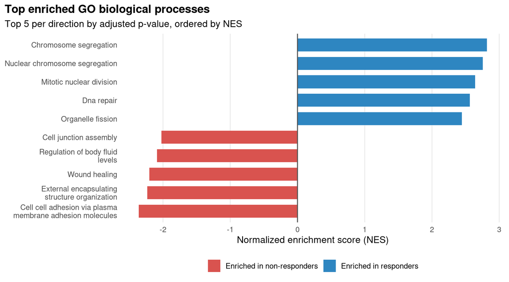

```r
top_pathways_df <- fgsea_tbl |>
  mutate(direction = if_else(NES > 0,
                             "Enriched in responders",
                             "Enriched in non-responders")) |>
  group_by(direction) |>
  slice_min(padj, n = 5, with_ties = FALSE) |>
  ungroup() |>
  mutate(label = clean_label(pathway, width = 30))

ggplot(top_pathways_df, aes(x = NES, y = reorder(label, NES), fill = direction)) +
  geom_col(width = 0.7) +
  geom_vline(xintercept = 0, color = "grey30") +
  scale_fill_manual(
    name = NULL,
    values = c("Enriched in responders"     = group_colours[["R"]],
               "Enriched in non-responders" = group_colours[["NR"]])
  ) +
  labs(x = "Normalized enrichment score (NES)",
       y = NULL,
       title = "Top enriched GO biological processes",
       subtitle = "Top 5 per direction by adjusted p-value, ordered by NES") +
  theme_minimal(base_size = 12) +
  theme(panel.grid.major.y = element_blank(),
        panel.grid.minor   = element_blank(),
        legend.position    = "bottom",
        plot.title         = element_text(face = "bold"),
        plot.title.position = "plot")
```

GO terms overlap heavily. The next step collapses them into independent themes.

### Collapse redundant pathways

```r
set.seed(42)

sig <- fgsea_res[padj < padj_cut][order(pval, -abs(NES))]
collapsedPathways <- collapsePathways(sig, pathways, ranked_genes, nperm = 1000)

main_pathways <- collapsedPathways$mainPathways
n_sig  <- nrow(sig)
n_main <- length(main_pathways)
```

```r
# Which pathways were absorbed by each main pathway?
parents  <- collapsedPathways$parentPathways
children <- tibble(pathway = names(parents), parent = parents) |>
  filter(!is.na(parent))

children |>
  group_by(parent) |>
  summarise(n_absorbed = n(),
            examples   = paste(head(pathway, 4), collapse = "; ")) |>
  arrange(desc(n_absorbed))
```

```
# A tibble: 189 × 3
   parent                                     n_absorbed examples
   <chr>                                           <int> <chr>
 1 GOBP_UROGENITAL_SYSTEM_DEVELOPMENT                 42 GOBP_MESONEPHROS_DEVEL…
 2 GOBP_WOUND_HEALING                                 40 GOBP_HEMOSTASIS; GOBP_…
 3 GOBP_DNA_REPAIR                                    30 GOBP_DOUBLE_STRAND_BRE…
 4 GOBP_LIPID_LOCALIZATION                            30 GOBP_REGULATION_OF_LIP…
 5 GOBP_REGULATION_OF_HORMONE_LEVELS                  30 GOBP_HORMONE_TRANSPORT…
 6 GOBP_CHROMOSOME_SEGREGATION                        28 GOBP_NUCLEAR_CHROMOSOM…
 7 GOBP_REGULATION_OF_INNATE_IMMUNE_RESPONSE          23 GOBP_REGULATION_OF_RES…
 8 GOBP_NATURAL_KILLER_CELL_MEDIATED_IMMUNITY         22 GOBP_REGULATION_OF_NAT…
 9 GOBP_AMEBOIDAL_TYPE_CELL_MIGRATION                 20 GOBP_REGULATION_OF_EPI…
10 GOBP_RIBONUCLEOPROTEIN_COMPLEX_BIOGENESIS          18 GOBP_RIBOSOME_BIOGENES…
# ℹ 179 more rows
```

```r
# Statistics for the main (collapsed) pathways only
main_tbl <- fgsea_tbl |>
  filter(pathway %in% main_pathways) |>
  mutate(direction = if_else(NES > 0,
                             "Enriched in responders",
                             "Enriched in non-responders"),
         label = clean_label(pathway))

main_tbl |>
  dplyr::count(direction)
```

```
# A tibble: 2 × 2
  direction                      n
  <chr>                      <int>
1 Enriched in non-responders   237
2 Enriched in responders       110
```

```r
# Top 10 main pathways per direction
main_tbl |>
  group_by(direction) |>
  slice_min(padj, n = 10, with_ties = FALSE) |>
  ungroup() |>
  arrange(direction, padj) |>
  select(label, direction, NES, padj, size)
```

```
# A tibble: 20 × 5
   label                                          direction   NES     padj  size
   <chr>                                          <chr>     <dbl>    <dbl> <int>
 1 Wound healing                                  Enriched… -2.20 1.44e-17   411
 2 Cell cell adhesion via plasma membrane adhesi… Enriched… -2.36 1.33e-16   268
 3 External encapsulating structure organization  Enriched… -2.23 5.42e-15   303
 4 Cell junction assembly                         Enriched… -2.02 4.28e-13   410
 5 Regulation of body fluid levels                Enriched… -2.09 6.45e-13   376
 6 Homophilic cell adhesion via plasma membrane … Enriched… -2.39 1.01e-12   165
 7 Regulation of hormone levels                   Enriched… -1.96 3.57e-12   488
 8 Urogenital system development                  Enriched… -2.05 1.29e-11   350
 9 Negative regulation of hydrolase activity      Enriched… -2.01 7.05e-11   343
10 Regulation of wound healing                    Enriched… -2.34 4.92e-10   123
11 Dna repair                                     Enriched…  2.56 1.14e-29   481
12 Chromosome segregation                         Enriched…  2.82 1.37e-29   317
13 Organelle fission                              Enriched…  2.44 2.34e-24   457
14 Mitotic nuclear division                       Enriched…  2.64 9.78e-23   283
15 Dna replication                                Enriched…  2.62 3.92e-21   271
16 Sister chromatid segregation                   Enriched…  2.81 5.66e-21   194
17 Ribonucleoprotein complex biogenesis           Enriched…  2.32 5.35e-19   414
18 Dna recombination                              Enriched…  2.51 1.36e-18   285
19 Dna dependent dna replication                  Enriched…  2.85 1.66e-18   154
20 Cell cycle phase transition                    Enriched…  2.12 4.10e-16   490
```

```r
fgsea_tbl |>
  mutate(direction = if_else(NES > 0,
                             "Enriched in responders",
                             "Enriched in non-responders"),
         label = clean_label(pathway)) %>%
  group_by(direction) |>
  slice_min(padj, n = 10, with_ties = FALSE) |>
  ungroup() |>
  arrange(direction, padj) |>
  select(label, direction, NES, padj, size)
```

```
# A tibble: 20 × 5
   label                                          direction   NES     padj  size
   <chr>                                          <chr>     <dbl>    <dbl> <int>
 1 Wound healing                                  Enriched… -2.20 1.44e-17   411
 2 Cell cell adhesion via plasma membrane adhesi… Enriched… -2.36 1.33e-16   268
 3 External encapsulating structure organization  Enriched… -2.23 5.42e-15   303
 4 Cell junction assembly                         Enriched… -2.02 4.28e-13   410
 5 Regulation of body fluid levels                Enriched… -2.09 6.45e-13   376
 6 Homophilic cell adhesion via plasma membrane … Enriched… -2.39 1.01e-12   165
 7 Regulation of hormone levels                   Enriched… -1.96 3.57e-12   488
 8 Hemostasis                                     Enriched… -2.21 1.12e-11   224
 9 Urogenital system development                  Enriched… -2.05 1.29e-11   350
10 Negative regulation of hydrolase activity      Enriched… -2.01 7.05e-11   343
11 Dna repair                                     Enriched…  2.56 1.14e-29   481
12 Chromosome segregation                         Enriched…  2.82 1.37e-29   317
13 Organelle fission                              Enriched…  2.44 2.34e-24   457
14 Nuclear chromosome segregation                 Enriched…  2.75 2.85e-23   261
15 Mitotic nuclear division                       Enriched…  2.64 9.78e-23   283
16 Dna replication                                Enriched…  2.62 3.92e-21   271
17 Sister chromatid segregation                   Enriched…  2.81 5.66e-21   194
18 Mitotic sister chromatid segregation           Enriched…  2.88 1.65e-20   165
19 Double strand break repair                     Enriched…  2.65 3.02e-20   244
20 Ribonucleoprotein complex biogenesis           Enriched…  2.32 5.35e-19   414
```

#### Interpretation

**Responders** are higher in pathways that are associated with active cell proliferation/cell division,

In the context of anti-PD-L1 treatment, this makes sense because the treatment releases the brakes on the immune system, reflecting a more proliferative tumour environment, potentially including increased immune-cell proliferation and expansion of activated lymphocytes.

However, these pathways are not specific to immune cells. They could also reflect proliferation of tumour cells. Therefore, it is important to examine which cell populations contribute to the signal.

In the article, they find that high TMB is related to treatment response, so it might be a result of this, that the reponders are high. Correlational, not causal (?)

**Non-responders** are higher in extracellular matrix remodelling which may indicate a new tumor microenvironment, as well as positive vascular development a driver of angiogenesis.

Tissue remodeling is also very much in alignment with the findings from the article

### GSEA table for the main pathways

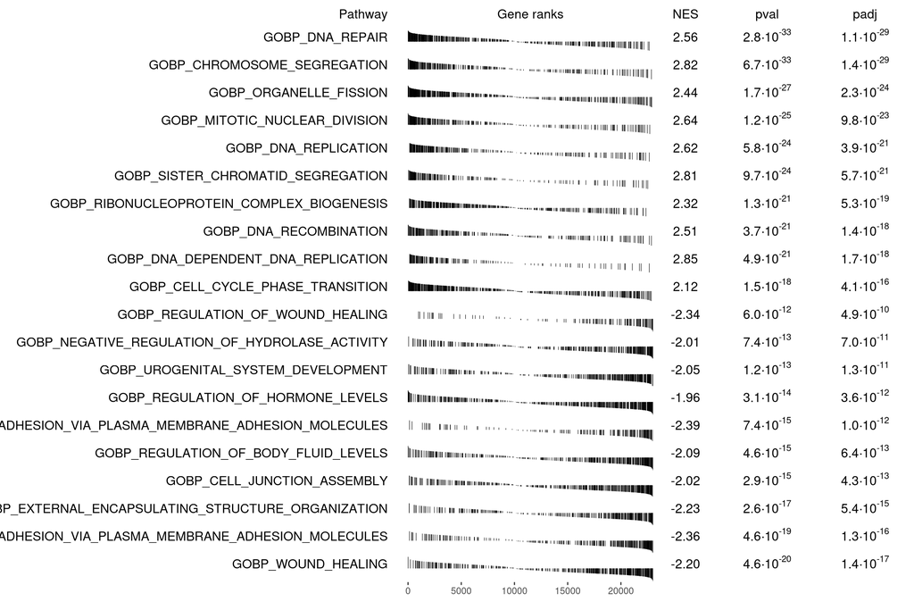

```r
top_main_up <- main_tbl |>
  filter(NES > 0) |>
  slice_min(padj, n = 10, with_ties = FALSE) |>
  pull(pathway)

top_main_down <- main_tbl |>
  filter(NES < 0) |>
  slice_min(padj, n = 10, with_ties = FALSE) |>
  pull(pathway)


# gseaParam = 0.5 only affects how the plot is drawn, not the statistics
plotGseaTable(pathways[c(top_main_up, rev(top_main_down))],
              stats     = ranked_genes,
              fgseaRes  = main_tbl,
              gseaParam = 0.5)
```

### Enrichment plots for the top main pathway in each direction

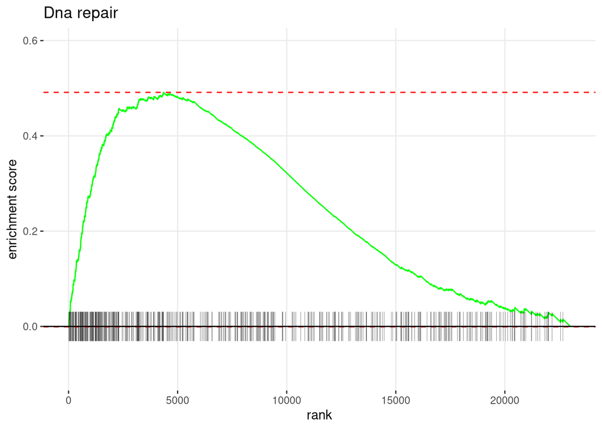

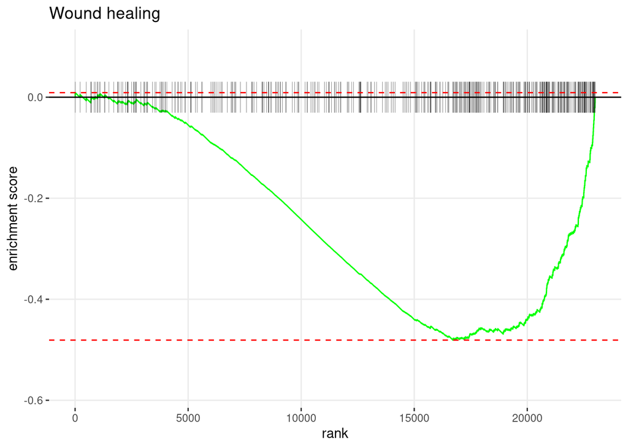

```r
top_up <- main_tbl |>
  filter(NES > 0) |>
  slice_min(padj, n = 1, with_ties = FALSE) |>
  pull(pathway)

top_down <- main_tbl |>
  filter(NES < 0) |>
  slice_min(padj, n = 1, with_ties = FALSE) |>
  pull(pathway)

plot_pw <- function(pw) {
  es <- fgsea_tbl$ES[fgsea_tbl$pathway == pw]
  plotEnrichment(pathways[[pw]], ranked_genes, ticksSize = 0.08) +
    labs(title = clean_label(pw, width = 60)) +
    coord_cartesian(ylim = sort(c(0, es)) + c(-0.1, 0.1))
}

# Loop + print() so that a direction without any main pathway is simply skipped
for (pw in c(top_up, top_down)) print(plot_pw(pw))
```

### Volcano plot of the collapsed pathways

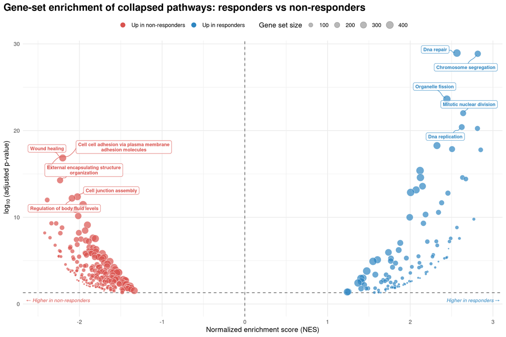

```r
# All collapsed (independent) main pathways, not only the top 10 per direction
nes_df <- main_tbl |>
  mutate(
    label = clean_label(pathway, width = 40),
    group = case_when(
      padj < padj_cut & NES > 0 ~ "Up in responders",
      padj < padj_cut & NES < 0 ~ "Up in non-responders",
      TRUE ~ "Not significant"
    )
  ) |>
  arrange(group != "Not significant")   # draw significant points on top

nes_df_alternative <- fgsea_tbl |>
  mutate(label = clean_label(pathway),
         group = case_when(
      NES > 0 & pathway %in% main_pathways ~ "Up in responders",
      NES < 0 & pathway %in% main_pathways ~ "Up in non-responders",
      padj > padj_cut ~ "Not significant",
      TRUE ~ "Not main pathways")) %>%
  filter(group != "Not main pathways") |> # remove non-main pathways
  arrange(group != "Not significant")   # draw significant points on top

# Label the 5 most significant main pathways in each direction
nes_labels <- nes_df |>
  filter(group != "Not significant") |>
  group_by(group) |>
  slice_min(padj, n = 5, with_ties = FALSE) |>
  ungroup()

p <- ggplot(nes_df, aes(x = NES, y = -log10(padj))) +
  geom_vline(xintercept = 0, linetype = "dashed", color = "grey40") +
  geom_hline(yintercept = -log10(padj_cut), linetype = "dashed", color = "grey40") +
  geom_point(aes(size = size, fill = group),
             shape = 21, colour = "white", stroke = 0.35, alpha = 0.7) +
  scale_color_manual(
    name = NULL,
    values = c("Up in responders"     = group_colours[["R"]],
               "Up in non-responders" = group_colours[["NR"]],
               "Not significant"      = "grey80"),
    aesthetics = c("color", "fill")
  ) +
  scale_size_continuous(name = "Gene set size", range = c(1, 6)) +
  geom_label_repel(
    data = nes_labels,
    aes(label = label, colour = group),
    size = 2.9, lineheight = 0.9, fontface = "bold",
    fill = alpha("white", 0.7), label.size = 0.25,
    label.r = unit(0.2, "lines"), label.padding = unit(0.25, "lines"),
    box.padding = 0.6, point.padding = 0.4, min.segment.length = 0,
    segment.size = 0.35, segment.curvature = -0.15, segment.ncp = 3,
    segment.inflect = TRUE, max.overlaps = Inf, seed = 42,
    show.legend = FALSE
  ) +
  annotate("text", x = Inf, y = 0, label = "Higher in responders \u2192",
           hjust = 1.05, vjust = -0.5, size = 3,
           fontface = "italic", color = group_colours[["R"]]) +
  annotate("text", x = -Inf, y = 0, label = "\u2190 Higher in non-responders",
           hjust = -0.05, vjust = -0.5, size = 3,
           fontface = "italic", color = group_colours[["NR"]]) +
  guides(
    fill = guide_legend(order = 1,
                        override.aes = list(size = 4, alpha = 1)),
    size = guide_legend(order = 2,
                        override.aes = list(fill = "grey60", colour = "grey40",
                                            alpha = 0.7))
  ) +
  labs(x = "Normalized enrichment score (NES)",
       y = expression(-log[10]~"(adjusted p-value)"),
       title = "Gene-set enrichment of collapsed pathways: responders vs non-responders") +
  theme_minimal(base_size = 12) +
  theme(plot.title.position = "plot",
        legend.position     = "top",
        plot.title          = element_text(face = "bold", size = 17))

p
```

```r
dir.create("images", showWarnings = FALSE)
ggsave("images/gsea_volcano.pdf", p, width = 10, height = 6, device = cairo_pdf)
```